# 2IsoClrMVN

Emma Govan

6/7/2022

## Introduction

This file contains the maths and code for running a simple stable isotope mixing model through a Fixed Form Variational Bayes (FFVB) algorithm. The text below introduces the model, outlines the algorithm, fits the model using MCMC (via JAGS) and then fits the FFVB algorithm. Finally the two approaches are compared using plots of the derived posterior distributions.

## Model

We use the likelihood:

$$y_{i} \sim N(\sum_{k=1}^Kp_k\mu_{k},
\tau^{-1})$$

where $y$ is the data and $p$ and $\tau$ are the parameters to be estimated.

We use the following prior distributions for $p$ and $\tau$:

$[p_1,...p_k] = \frac{\exp(f)}{\Sigma\exp(f)}$

$f \sim mvn(\mu_f, \Sigma_f)$

$\tau \sim Ga(c, d)$

Priors for f and tau:

$$\pi(f) =
\frac{1}{(2\pi)^\frac{n}{2}}\frac{1}{\mid(\Sigma_{f0})\mid^{\frac{1}{2}}}
\exp\left(-\frac{1}{2}(f-\mu_{f0})^T\Sigma_{f0}^{-1}(f-\mu_{f0})\right)$$
But we just use sum dnorm here

$$\pi(\tau) =
\frac{d_0^{c_0}}{\Gamma(c_0)} \tau_j^{c_0-1} \exp(-d_0\tau_j)$$
Here $\mu_{f0}, \Sigma_{f0}, c_0$, and $d_0$ are all fixed.

## Fixed Form Variational Inference

The algorithm detailed below comes from Algorithm 4 [here](https://vbayeslab.github.io/VBLabDocs/tutorial/ffvb).

If we define the joint set of parameters as $\theta = (f, \tau)$ then we write the factorised variational posterior as:

$$q_\lambda(\theta) =
q(f)q(\tau)$$

where $\lambda = (\mu_f, \Sigma_f, c, d)^T$ is the set of hyper-parameters associated with the variational posteriors:

$$q(f) \equiv mvn(\mu_f,
\Sigma_f)$$

$$q(\tau) \equiv Ga(c,d)$$

We use parenthetical super-scripts to denote iterations. To start the algorithm, initial values are required for $\lambda^{(0)}$, the sample size $S$, the adaptive learning weights ($\beta_1, \beta_2$), the fixed learning rate $\epsilon_0$, the threshold $\tau$, the rolling window size $t_W$ and the maximum patience $P$.

Define $h$ to be the log of the joint distribution up to the constant of proportionality:

$$h(\theta) = \log \left( p(y|\theta)
p(\theta) \right)$$
and $h_\lambda$ to be the log of the ratio between the joint and the VB posterior:

$$h_\lambda(\theta) = \log \left( \frac{
p(y|\theta) p(\theta) }{ q_\lambda(\theta) } \right) = h(\theta) - \log
q_\lambda(\theta)$$

The initialisation stage proceeds with:

1. Generate samples from $\theta_s \sim q_{\lambda^{(0)}(\theta)}$ for $s=1,...S$
2. Compute the unbiased estimate of the lower bound gradient:
   $$\widehat{\nabla_\lambda{LB}(\lambda^{(0)})} =
   \frac{1}{S}\sum_{s=1}^S\nabla_\lambda[\log(q_\lambda(\theta_s))] \circ
   h_\lambda(\theta_s) \bigg\rvert_{\lambda = \lambda^{(0)}}$$
   where $\circ$ indicates elementwise multiplication
3. Set $\bar{g}_0 := \nabla_\lambda{LB}(\lambda^{(0)})$, $\bar{\nu_0} := \bar{g_0}^2$, $\bar{g} = g_0$, $\bar{\nu} = \nu_0$
4. Estimate the control variate $c_i$ for the $i$th element of $\lambda$ as:
   $$c_i = \frac{Cov
   \left(\nabla_{\lambda_i}[\log(q_\lambda(\theta))]h_\lambda(\theta),\nabla_{\lambda_i}[\log(q_\lambda(\theta))]\right)}{
   Var(\nabla_{\lambda_i}[\log(q_\lambda(\theta))])}$$

across the samples generated in step 1 5. Set $t=1$, patience = 0, and `stop = FALSE`

Now the algorithm runs with:

1. Generate samples from $\theta_s \sim q_{\lambda^{(t)}(\theta)}$ for $s=1,...S$
2. Compute the unbiased estimate of the lower bound gradient:
   $$g_t :=
   \widehat{\nabla_\lambda{LB}(\lambda^{(t)})} =
   \frac{1}{S}\sum_{s=1}^S\nabla_\lambda[\log(q_\lambda(\theta_s))]
   \circ(h_\lambda(\theta_s) - c) \bigg\rvert_{\lambda =
   \lambda^{(t)}}$$

where $\circ$ indicates elementwise multiplication. 3. Estimate the new control variate $c_i$ for the $i$th element of $\lambda$ as:
$$c_i = \frac{Cov
\left(\nabla_{\lambda_i}[\log(q_\lambda(\theta))]h_\lambda(\theta),\nabla_{\lambda_i}[\log(q_\lambda(\theta))]\right)}{
Var(\nabla_{\lambda_i}[\log(q_\lambda(\theta))])}$$
across the samples generated in step 1 4. Compute:
$$\begin{eqnarray}
v_t &=& g_t^2 \\
\bar{g} &=& \beta_1\bar{g} + (1-\beta_1)g_t \\
\bar{v} &=& \beta_2\bar{v} + (1-\beta_2)v_t \\
\end{eqnarray}$$
5. Update the learning rate: $l_t = min(\epsilon_0, \epsilon_0\frac{\tau}{t})$ and the variational hyper-parameters:
$$\lambda^{(t+1)} = \lambda^{(t)} +
l_t\frac{\bar{g}}{\sqrt{\bar{v}}}$$

6. Compute the lower bound estimate:
   $$\widehat{LB}(\lambda^{(t)}) := \frac{1}{S}
   \sum_{s=1}^S h_{\lambda^{(t)}}(\theta_s)$$
7. If $t \ge t_W$ compute the moving average LB
   $$\overline{LB}_{t-t_W+1} :=
   \frac{1}{t_W} \sum_{k=1}^{t_W} \widehat{LB}(\lambda^{(t-k +
   1)})$$
   If $\overline{LB}_{t-t_W+1} \ge \max(\bar{LB})$ patience = 0, else patience = patience +1
8. If patience $\ge$ P, `stop = TRUE`
9. Set $t:=t+1$

## Data and hyper-parameters

The data set we use is defined as follows:

```r
col1<-rnorm(10, mean = 1, sd =0.2)
col2<-rnorm(10, mean = 1, sd=0.2)
y<-matrix(c(col1, col2), ncol = 2, byrow = FALSE)
colnames(y)<-c("d15N", "d13C")
y<-as.data.frame(y)
n<-nrow(y)
```

The hyper-parameter values for the prior distributions:

```r
c_0 <- c(1,1)
d_0 <- c(1,1)
n_isotopes <- 2

mu_kj <- matrix(c(1,10,1,10), nrow = 2)
colnames(mu_kj)<-c("Meand15N", "Meand13C")
K<-nrow(mu_kj)
```

## JAGS code for comparison

As a benchmark, we fit this model using JAGS with the following code:

```r
model_code <- "
model{
  # Likelihood
  for (j in 1:J) {
    for (i in 1:N) {
      y[i,j] ~ dnorm(inprod(p, s_mean[,j]), tau[j])
    }

  }
  # Prior on sigma
  for(j in 1:J) { tau[j] ~ dgamma(1,1) }
  # CLR prior on p
  p[1:K] <- expf/sum(expf)
  for(k in 1:K) {
    expf[k] <- exp(f[k])
    f[k] ~ dnorm(mu_f_mean[k],1/pow(sigma_f_sd[k],2))
  }
}
"

# Set up the data - these match the data objects in the jags code
model_data <- list(
  N = length(y),
  y = y,
  s_mean = mu_kj,
  #c_mean = mu_c,
  #s_sd = sigma_kj,
  #c_sd = sigma_c,
  #q = q,
  K = K,
  J = n_isotopes,
  mu_f_mean = c(rep(0, K)),
  sigma_f_sd = c(rep(1, K))
)

# Choose which parameters to save
model_parameters <- c("p", "tau", "f")



# Run the model
model_run <- jags(
  data = model_data,
  parameters.to.save = model_parameters,
  model.file = textConnection(model_code),
  n.chains = 4, # Number of different starting positions
  n.iter = 10000, # Number of iterations
  n.burnin = 2000, # Number of iterations to remove at start
  n.thin = 5
) # Amount of thinning)
```

Print the output

```r
print(model_run)
```

```
## Inference for Bugs model at "4", fit using jags,
##  4 chains, each with 10000 iterations (first 2000 discarded), n.thin = 5
##  n.sims = 6400 iterations saved
##          mu.vect sd.vect   2.5%    25%    50%    75%  97.5%  Rhat n.eff
## f[1]       1.492   0.786 -0.011  0.949  1.470  2.024  3.042 1.001  6400
## f[2]      -1.499   0.781 -3.045 -2.031 -1.489 -0.970  0.028 1.001  6400
## p[1]       0.943   0.036  0.853  0.925  0.950  0.968  0.989 1.001  6400
## p[2]       0.057   0.036  0.011  0.032  0.050  0.075  0.147 1.001  6400
## tau[1]     1.492   1.127  0.165  0.672  1.204  2.031  4.278 1.001  6400
## tau[2]     1.738   1.310  0.201  0.783  1.412  2.334  5.164 1.001  6400
## deviance   8.239   2.901  3.478  6.183  7.921  9.926 14.709 1.001  6400
##
## For each parameter, n.eff is a crude measure of effective sample size,
## and Rhat is the potential scale reduction factor (at convergence, Rhat=1).
##
## DIC info (using the rule, pD = var(deviance)/2)
## pD = 4.2 and DIC = 12.4
## DIC is an estimate of expected predictive error (lower deviance is better).
```

## FFVB definitions for this model

$$\pi(y_{i} | p, \tau) =
\frac{1}{\sqrt{(2\pi)}} (\sum_{k=1}^Kp_k^2\sigma_{k}^2 +
\tau^{-1})^{\frac{n}{2}} \exp\left(-\frac{(\sum_{k=1}^Kp_k^2\sigma_{k}^2
+ \tau^{-1})}{2} \sum_{i=1}^n\left(y_{i} -
\sum_{k=1}^Kp_k\mu_{k}\right)^2\right)$$

$$q(f) =
\frac{1}{(2\pi)^\frac{n}{2}}\frac{1}{\mid(\Sigma_f)\mid^{\frac{1}{2}}}
\exp\left(-\frac{1}{2}(f-\mu_f)^T\Sigma_f^{-1}(f-\mu_f)\right)$$
$$q(\tau) = \frac{d^{c}}{\Gamma(c)}
\tau_j^{c-1} \exp(-d\tau_j)$$

$$h(\theta) = \log(\pi(f)\pi(\tau)\pi(y|f,
\tau))$$

$\log{q_\lambda}(\theta) = \log(q(f)q(\tau))$

## FFVB code for this model

```r
# This code runs simple SIMM with just the generic functions

# Source in all the generic functions
source("FF_VB_generic_functions_correct.R")

# Set up data and priors --------------------------------------------------

rMVNormC <- function(n, mu, U){
  p <- length(mu)
  Z <- matrix(rnorm(p*n), p, n)
  # U <- chol(Omega) # By default R's chol fxn returns upper cholesky factor
  X <- backsolve(U, Z) # more efficient and stable than actually inverting
  X <- sweep(X, 1, mu, FUN=`+`)
  return(X)
}


# Hyper-parameters - vague priors
S<-100
fmean_0 <-c(rep(0, K))
fsd_0<-c(rep(1,K))

# Functions for this model ------------------------------------------------

# Simulate from theta - always MVN in this example
sim_theta <- function(S, lambda) {

  # For K parameters you will have
  # lambda is of length K+K*(K+1)/2 +n_isotopes*2
  # mean <- lambda[1:K]
  # chol_prec is made up of lambda[(K + 1):(K+(K*(K+1))/2)]
  #Tau is made up of lambda[((K+(K*(K+1))/2)+1):((K+(K*(K+1))/2)+n_isotopes*2)]
  # (f) ~ MVN(lambda[1:K], solve(crossprod(chol_prec)))

  mean <- lambda[1:K]
  # K*(K-1) precision terms
  chol_prec <- matrix(0, nrow = K, ncol = K)
  chol_prec[upper.tri(chol_prec, diag = TRUE)] <- lambda[(K + 1):(K+(K*(K+1))/2)]

  # This is a placeholder for more advanced code using chol_prec directly
  theta <- cbind(t(rMVNormC(S, mu = mean, U = chol_prec)),
           matrix(rgamma(S*n_isotopes,
                 shape = lambda[((K+(K*(K+1))/2)+1):(((K+(K*(K+1))/2))+n_isotopes)],
                 rate = lambda[(((K+(K*(K+1))/2))+n_isotopes+1):(((K+(K*(K+1))/2))+n_isotopes*2)]),
                 nrow = S,
                 ncol = n_isotopes,
                 byrow = TRUE))


}
# K <- 3; lambda <- c(rnorm(K+K*(K+1)/2), rgamma(n_isotopes*2, 1,1))
# theta <- sim_theta(50, lambda)

#Theta is f and tau


# Log of likelihood added to prior
h <- function(theta) {
  p <- exp(theta[1:K])/(sum((exp(theta[1:K]))))
        return(sum(dnorm(y[,1],
            mean = sum(p * mu_kj[,1]),
            sd = sqrt(1 / theta[K+1]),
            log = TRUE)) +
          sum(dnorm(y[,2],
            mean = sum(p *mu_kj[,2]),
            sd = sqrt(1 / theta[K+2]),
            log = TRUE)) +
    sum(dnorm(theta[1:K], fmean_0, fsd_0, log = TRUE)) +
    sum(dgamma(theta[(K+1):(K+2)], shape = c_0, rate = d_0, log = TRUE)))
}
# h(theta[1,])

log_q <- function(lambda, theta) {
  mean <- lambda[1:K]
  # K*(K-1) precision terms
  chol_prec <- matrix(0, nrow = K, ncol = K)
  chol_prec[upper.tri(chol_prec, diag = TRUE)] <- lambda[(K + 1):(K+(K*(K+1))/2)]
  # chol_prec[1,3] <- 0

  # This is a placeholder for more advanced code using chol_prec directly
  prec <- crossprod(chol_prec)
  # dmvnorm(theta, mean = mean, sigma = solve(prec), log = TRUE)
  p1 <- matrix(theta[1:K] - mean, ncol = 1) #%*%chol_prec
  log_det <- unlist(determinant(prec, logarithm = TRUE))['modulus']
  return(-0.5*K*log(2*pi)-0.5*log_det - 0.5*t(p1)%*%prec%*%(p1)
  + sum(dgamma(theta[(K+1):(K+2)],
               shape = lambda[((K+(K*(K+1))/2)+1):(((K+(K*(K+1))/2))+n_isotopes)],
               rate = lambda[(((K+(K*(K+1))/2))+n_isotopes+1):(((K+(K*(K+1))/2))+n_isotopes*2)],
               log = TRUE)))
}
# log_q(lambda, theta[1,])

#I've added terms to the return part
#I think it was missing some of the log mvn pdf



# Algorithm ---------------------------------------------------------------


lambda <- run_VB(lambda = c(rep(0, K), rep(1,(((K*(K+1))/2)+n_isotopes*2)))) # Starting value of lambda
```

```
## [1] 10
## [1] 20
## [1] 30
## [1] 40
## [1] 50
## [1] 60
## [1] 70
## [1] 80
## [1] 90
## [1] 100
## [1] 110
## [1] 120
## [1] 130
## [1] 140
## [1] 150
```

[output cut: 31 more lines]

## Comparison Plots

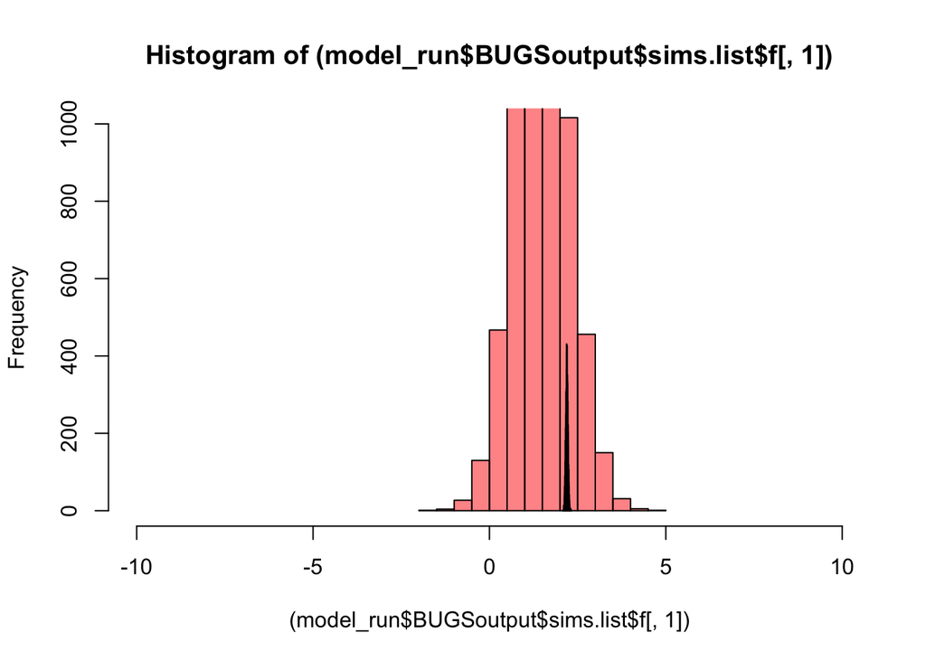

```r
mycol <- rgb(0, 0, 255, max = 255, alpha = 125, names = "blue50")
mycol2 <- rgb(255, 0, 0, max = 255, alpha = 125)

#Generate samples
theta <- sim_theta(6400, lambda)

f<-function(x){
  exp(x)/sum(exp(x))
  }

p<-t(apply(theta[,1:K], 1, f))



# Plot of F
hist((model_run$BUGSoutput$sims.list$f[,1]), col = mycol2, breaks = 20, ylim = c(0, 1000),
     xlim = c(-10, 10))
hist(theta[,1], col = mycol, alpha = 0.5, breaks = 40, add = TRUE)
```

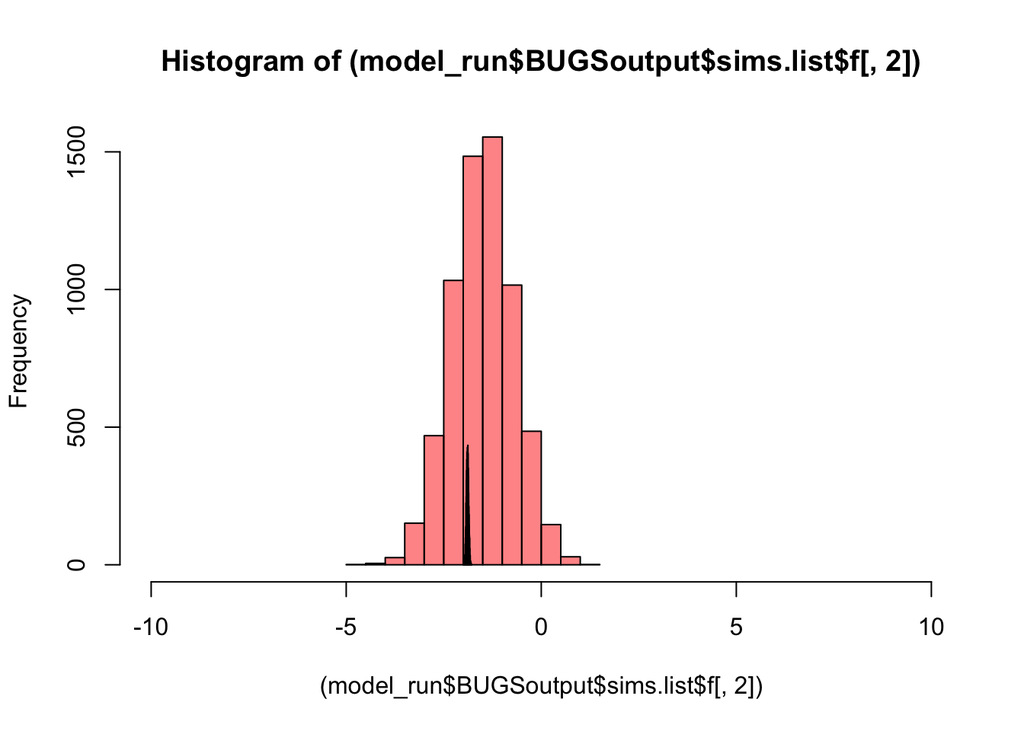

```r
hist((model_run$BUGSoutput$sims.list$f[,2]), col = mycol2, breaks = 20, xlim = c(-10, 10))
hist(theta[,2], col = mycol, add = TRUE, alpha = 0.5, breaks = 40)
```

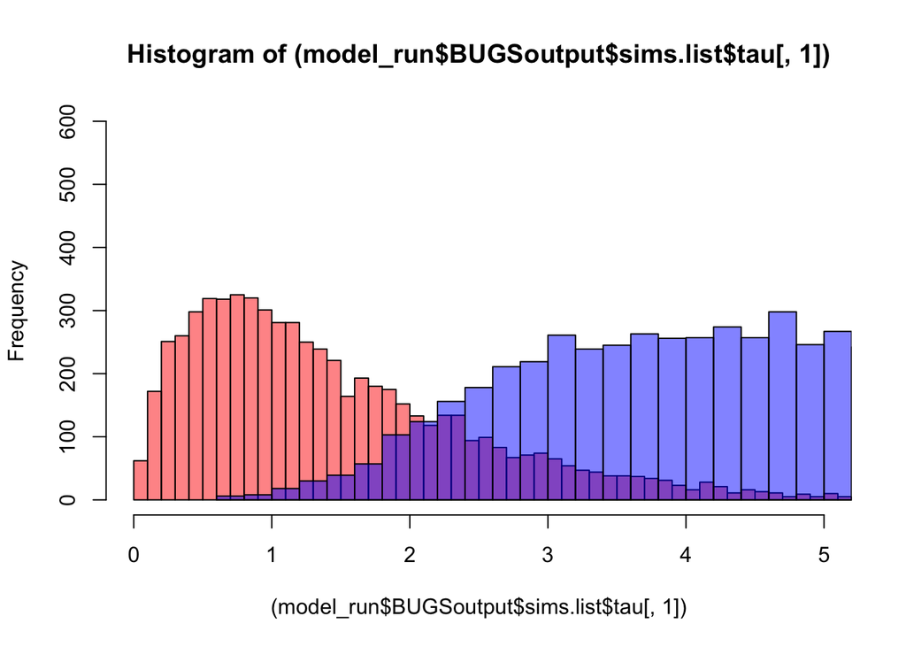

```r
# hist((model_run$BUGSoutput$sims.list$f[,3]), col = mycol2, breaks = 20, xlim = c(-10, 10))
# hist(theta[,3], col = mycol, add = TRUE, alpha = 0.5, breaks = 80)




# Plot of tau
hist((model_run$BUGSoutput$sims.list$tau[,1]), col = mycol2, breaks = 80, xlim = c(0, 5), ylim = c(0, 600))
hist((theta[,K+1]), add = TRUE, col = mycol, breaks = 80)
```

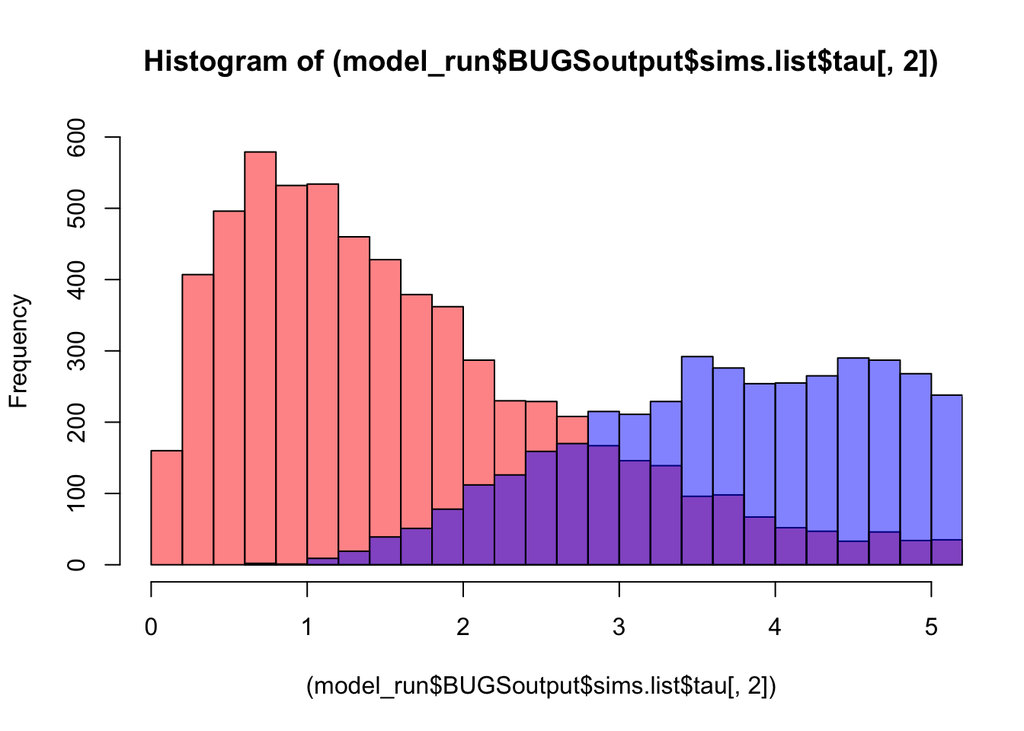

```r
hist((model_run$BUGSoutput$sims.list$tau[,2]), col = mycol2, breaks = 80, xlim = c(0, 5), ylim = c(0, 600))
hist((theta[,K+2]), add = TRUE, col = mycol, breaks = 80)
```

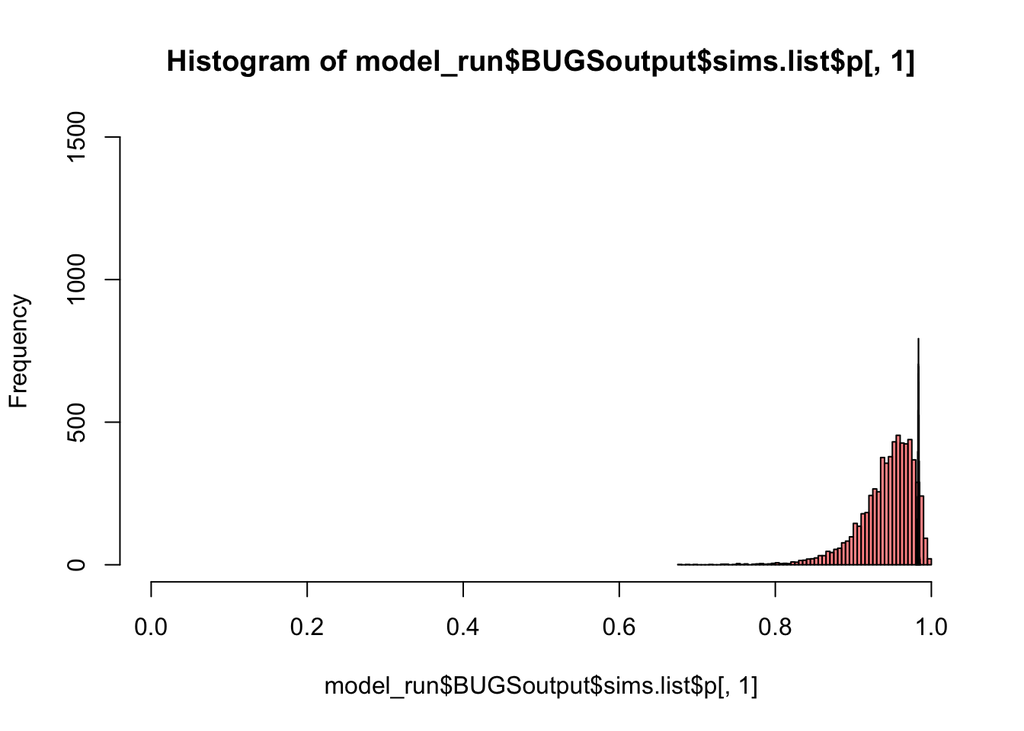

```r
#Plot of p

hist(model_run$BUGSoutput$sims.list$p[,1], col = mycol2, ylim = c(0, 1500), breaks = 80, xlim = c(0,1))
hist(p[,1], col = mycol, add = TRUE, breaks = 20)
```

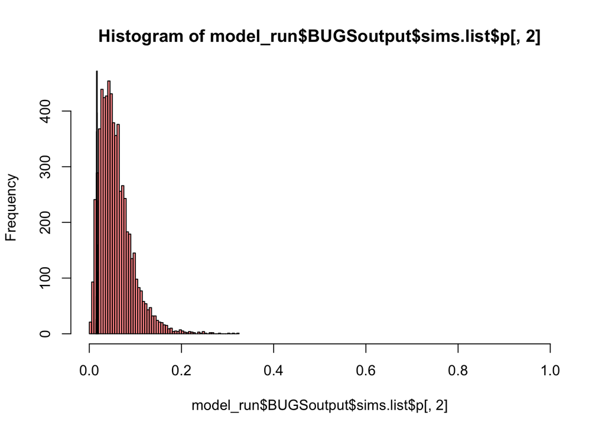

```r
hist(model_run$BUGSoutput$sims.list$p[,2], col = mycol2, breaks = 80, xlim = c(0,1))
hist(p[,2], col = mycol, add = TRUE, breaks = 20 )
```

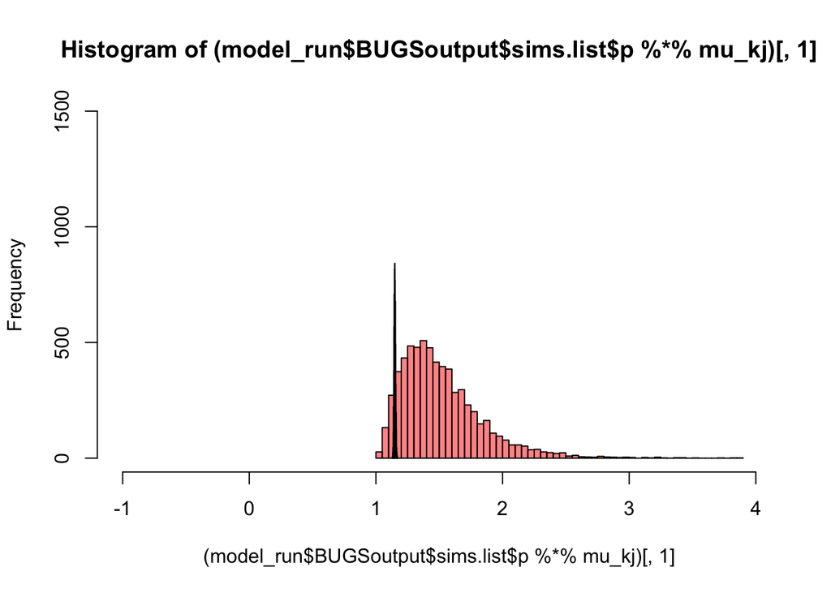

```r
# hist(model_run$BUGSoutput$sims.list$p[,3], breaks = 20, col = mycol2, ylim = c(0, 2500), xlim = c(0,1))
# hist(p[,3], col = mycol, add = TRUE, breaks = 20)

#Plot of mus
hist((model_run$BUGSoutput$sims.list$p%*%mu_kj)[,1], col = mycol2, breaks = 80, xlim = c(-1, 4), ylim = c(0, 1500))
hist((p%*%mu_kj)[,1], col = mycol, add = TRUE, breaks = 20)
```

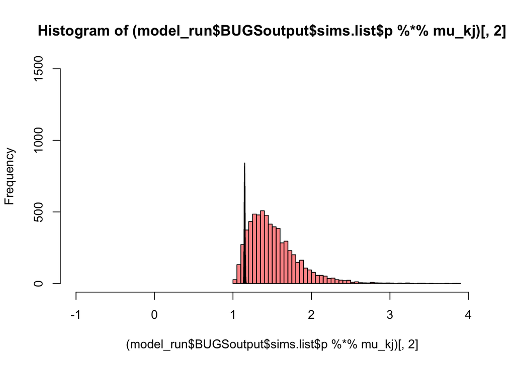

```r
hist((model_run$BUGSoutput$sims.list$p%*%mu_kj)[,2], col = mycol2, breaks = 80, ylim = c(0, 1500), xlim = c(-1, 4))
hist((p%*%mu_kj)[,2], col = mycol, add = TRUE, breaks = 20)
```

#Isosopace plot

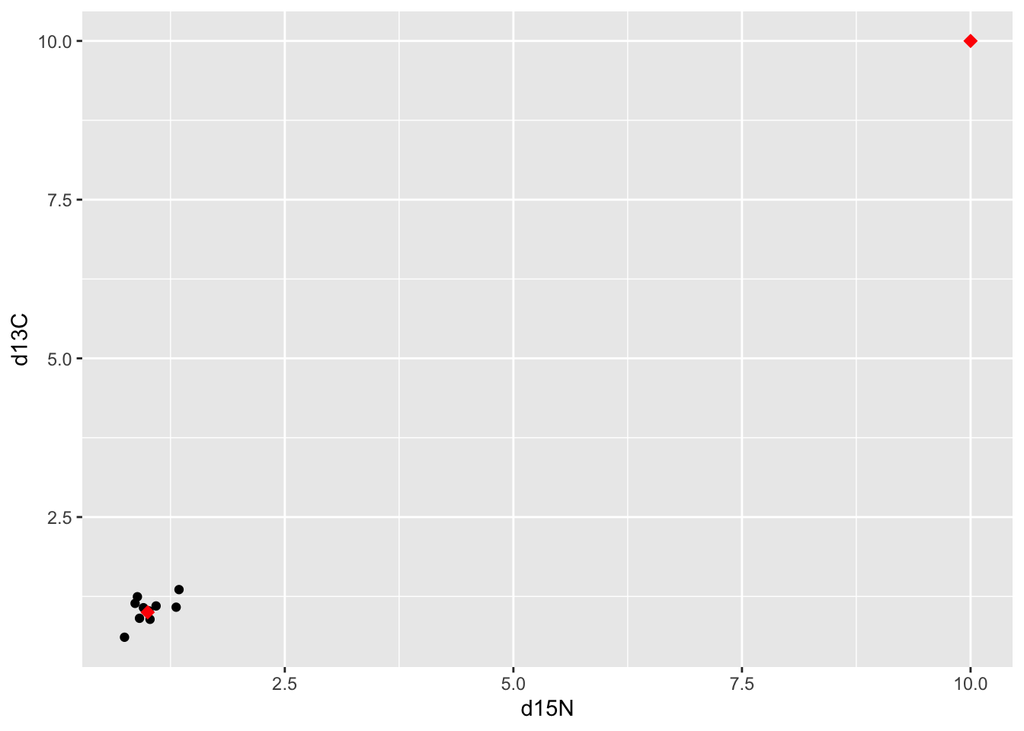

```r
ggplot() + geom_point(data = y, aes(x = d15N, y = d13C)) +geom_point(data = as.data.frame(mu_kj), aes(x = Meand15N, y = Meand13C), colour = "red", shape = 18, size = 3)
```